# GG Plot2

GGplot2 allows the user to add, remove or alter components in a plot at a high level of abstraction. Usually is loaded into R trough **tidyverse**, moreover there are many packages that extended ggplot2 as **ggforce!**

GGplot works with dataframe and not with single vectors. the main feature is possible to add features and layers over the plot! GGplot using the basic *ggplot* function to create a function does not assume what tipo of plot you want to use but it just take in the data that you are going to use. the *aes* function is used to tell ggplot what attributes you want to use! using *geom_smooth* it create a lines as which represent a regression specified into the method as “lm” and it also plot the ci.

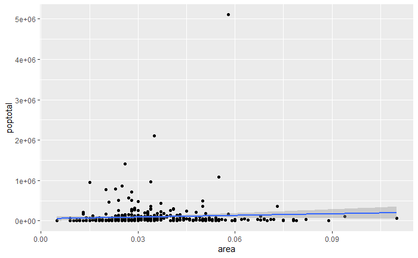

```r
library(ggplot2)
df <- ggplot2::midwest
ggplot(df, aes(x=area, y=poptotal))+
  geom_point()+
  geom_smooth(method="lm", se=T) #SE is the condidence interval
```

Change the *xlimits* and *ylimits*, having a numeric vector as argument:

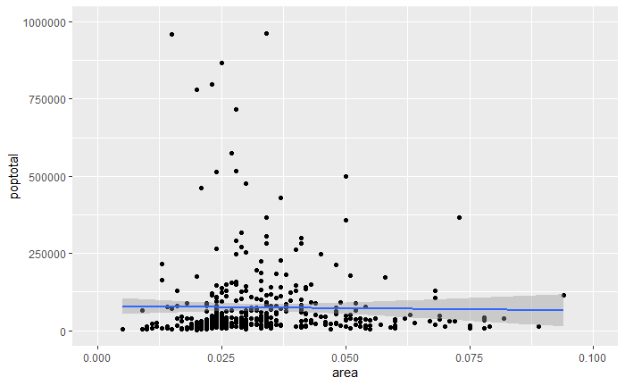

```r
df <- ggplot2::midwest
ggplot(df, aes(x=area, y=poptotal))+
  geom_point()+
  geom_smooth(method="lm", se=T)+
  xlim(c(0,0.1)) + ylim(c(0,1000000))
```

Is also possible to zoom in some region without delete the outliers point (which modify the regression line), to do that wr use *coord_cartesian* which will have the same results of limits but without modifying the line of best fit!

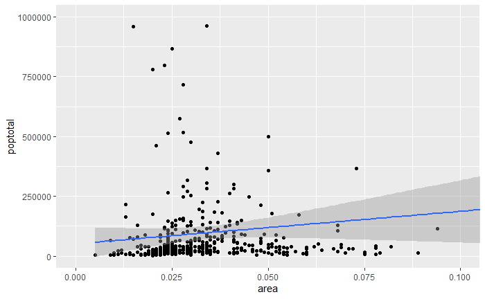

```r
df <- ggplot2::midwest
ggplot(df, aes(x=area, y=poptotal))+
  geom_point()+
  geom_smooth(method="lm", se=T)+
  coord_cartesian(xlim = c(0,0.1), ylim=c(0,1000000))
```

Other important details are the *title*, the *xlabel* and *ylabel*. is also possible to add each element one at time as *ggtitle*, *xlab* and *ylab* but is more convinient to use just one function **labs** and put insiede all those argument!

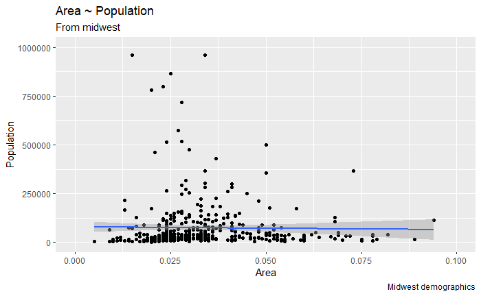

```r
df <- ggplot2::midwest
ggplot(df, aes(x=area, y=poptotal))+
  geom_point()+
  geom_smooth(method="lm", se=T)+
  xlim(c(0,0.1)) + ylim(c(0,1000000))+
  labs(title="Area ~ Population", subtitle = "From midwest", y="Population", x = "Area",caption="Midwest demographics")
```

Make the plot more color pleasant

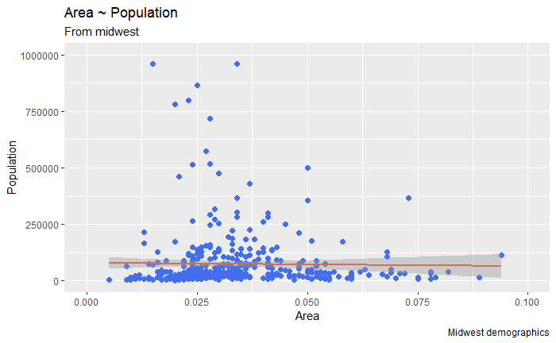

We can perform more useful function as coloring the points according to some other variable in the data frame. inside *geom_point* we insert inside the *aes* argument and specify that!

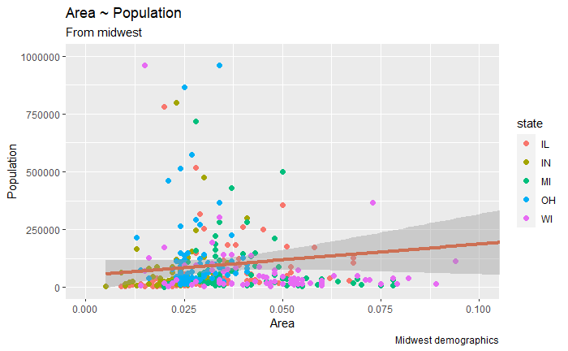

```r
df <- ggplot2::midwest
ggplot(df, aes(x=area, y=poptotal))+
  geom_point(aes(col=state), lwd=2)+
  geom_smooth(method="lm", se=T, size=1.5, col="salmon3")+
  coord_cartesian(xlim = c(0,0.1), ylim=c(0,1000000))+
  labs(title="Area ~ Population", subtitle = "From midwest",
       y="Population", x= "Area",
       caption="Midwest demographics")
```

Of course we can choice the palette we want by specifing *scale_color_brewer*!

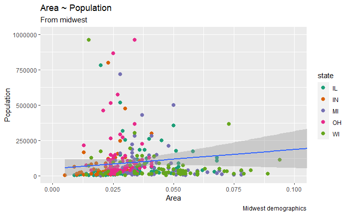

To see all the palettes:

|  | maxcolors | category | colorblind |
| --- | --- | --- | --- |
| BrBG | 11 | div | TRUE |
| PiYG | 11 | div | TRUE |
| PRGn | 11 | div | TRUE |
| PuOr | 11 | div | TRUE |
| RdBu | 11 | div | TRUE |
| RdGy | 11 | div | FALSE |
| RdYlBu | 11 | div | TRUE |
| RdYlGn | 11 | div | FALSE |
| Spectral | 11 | div | FALSE |
| Accent | 8 | qual | FALSE |

[output cut: 25 more lines]

We can specify the **xticks** and the **yticks** using the function *scale_x_continous*!is also possible to change the name of the ticks using *label* inside the function. in the same way we can *scale_y_continous*, inside these in the argument label we can even specify a function for create the labels!

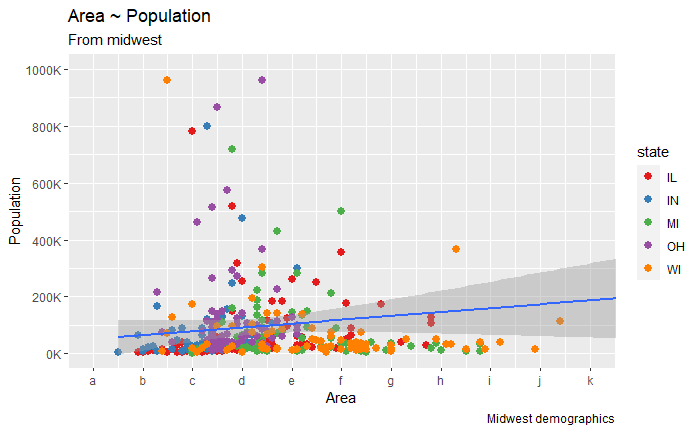

```r
df <- ggplot2::midwest
ggplot(df, aes(x=area, y=poptotal))+
  geom_point(aes(col=state), lwd=2.5)+
  geom_smooth(method="lm", se=T)+
  coord_cartesian(xlim = c(0,0.1), ylim=c(0,1000000))+
  labs(title="Area ~ Population", subtitle = "From midwest",
       y="Population", x= "Area",
       caption="Midwest demographics")+
  scale_colour_brewer(palette = "Set1")+

  scale_x_continuous(breaks=seq(0, 0.1, 0.01), labels=letters[1:11])+
  scale_y_continuous(breaks=seq(0, 1000000, 200000),
                     labels = function(x){paste0(x/1000, 'K')})
```

The concept of *theme* is also important, is possible to change the entire look of the graph using some already done graphics! all you insert after theme overwrite what you done before, in the example below the subtitle is overwrited!

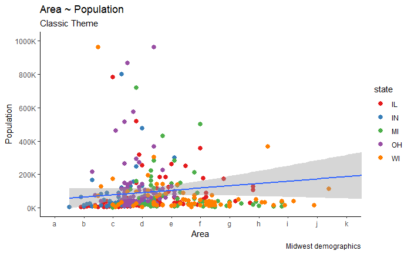

```r
df <- ggplot2::midwest
ggplot(df, aes(x=area, y=poptotal))+
  geom_point(aes(col=state), lwd=2.5)+
  geom_smooth(method="lm", se=T)+
  coord_cartesian(xlim = c(0,0.1), ylim=c(0,1000000))+
  labs(title="Area ~ Population", subtitle = "From midwest",
       y="Population", x= "Area",
       caption="Midwest demographics")+
  scale_colour_brewer(palette = "Set1")+

  scale_x_continuous(breaks=seq(0, 0.1, 0.01), labels=letters[1:11])+
  scale_y_continuous(breaks=seq(0, 1000000, 200000),
                     labels = function(x){paste0(x/1000, 'K')})+

  theme_classic() + labs(subtitle="Classic Theme")
```

For more customized and fancy themes have a look at the *ggthemes* package and the *ggthemr* package.

ggthemes have: flat, flat-dark, camoflauge, chalk, copper, dust, earth, fresh, grape, grass, greyscale, light, lilac, pale, sea, sky, solarized

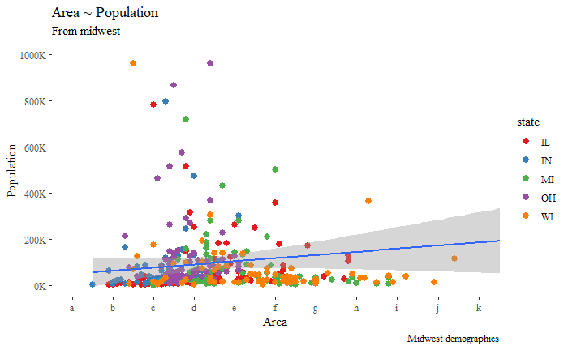

```r
library(ggthemes)
library(ggplot2)
df <- ggplot2::midwest
ggplot(df, aes(x=area, y=poptotal))+
  geom_point(aes(col=state), lwd=2.5)+
  geom_smooth(method="lm", se=T)+
  coord_cartesian(xlim = c(0,0.1), ylim=c(0,1000000))+
  labs(title="Area ~ Population", subtitle = "From midwest",
       y="Population", x= "Area",
       caption="Midwest demographics")+
  scale_colour_brewer(palette = "Set1")+

  scale_x_continuous(breaks=seq(0, 0.1, 0.01), labels=letters[1:11])+
  scale_y_continuous(breaks=seq(0, 1000000, 200000),
                     labels = function(x){paste0(x/1000, 'K')})+
  theme_tufte()
```

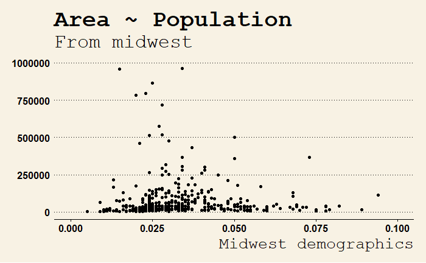

```r
df <- ggplot2::midwest
ggplot(df, aes(x=area, y=poptotal))+
  geom_point()+
  coord_cartesian(xlim = c(0,0.1), ylim=c(0,1000000))+
  labs(title="Area ~ Population", subtitle = "From midwest",
       y="Population", x= "Area",
       caption="Midwest demographics")+
  theme_wsj()
```

theme_base: a theme resembling the default base graphics in R. See also theme_par. theme_calc: a theme based on LibreOffice Calc. *theme_economist*: a theme based on the plots in the The Economist magazine. theme_excel: a theme replicating the classic ugly gray charts in Excel theme_few: theme from Stephen Few’s “Practical Rules for Using Color in Charts”. theme_fivethirtyeight: a theme based on the plots at fivethirtyeight.com. *theme_gdocs*: a theme based on Google Docs. theme_hc: a theme based on Highcharts JS. theme_par: a theme that uses the current values of the base graphics parameters in par. theme_pander: a theme to use with the pander package. theme_solarized: a theme using the solarized color palette. theme_stata: themes based on Stata graph schemes. *theme_tufte*: a minimal ink theme based on Tufte’s The Visual Display of Quantitativeinf theme_wsj: a theme based on the plots in the The Wall Street Journal.

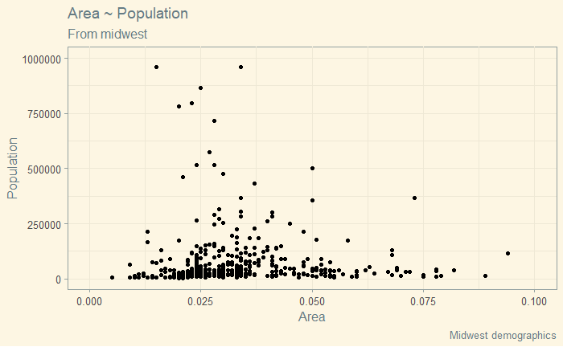

```r
df <- ggplot2::midwest
ggplot(df, aes(x=area, y=poptotal))+
  geom_point()+
  coord_cartesian(xlim = c(0,0.1), ylim=c(0,1000000))+
  labs(title="Area ~ Population", subtitle = "From midwest",
       y="Population", x= "Area",
       caption="Midwest demographics")+
  theme_solarized()
```

Modify the legend using the command *scale_color_discrete* or *scale_color_continous* according to the type of variable that we are representing! using the *guide* command we can also decide to do not show a particular legend!

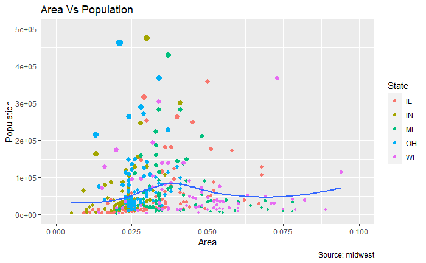

```r
gg <- ggplot(midwest, aes(x=area, y=poptotal)) +
  geom_point(aes(col=state, size=popdensity)) +
  geom_smooth(method="loess", se=F) + xlim(c(0, 0.1)) + ylim(c(0, 500000)) +
  labs(title="Area Vs Population", y="Population", x="Area", caption="Source: midwest")
# Modify Legend
gg + scale_color_discrete(name="State") + scale_size_continuous(name = "Density", guide = F)
```

We can also customize the legends for instance having the entire name of the state and not just the initial. manually we can:

```r
gg <- ggplot(midwest, aes(x=area, y=poptotal)) +
  geom_point(aes(col=state, size=popdensity)) +
  geom_smooth(method="loess", se=F) + xlim(c(0, 0.1)) + ylim(c(0, 500000)) +
  labs(title="Area Vs Population", y="Population", x="Area", caption="Source: midwest")+
  scale_color_manual(name="State",
                        labels = c("Illinois",
                                   "Indiana",
                                   "Michigan",
                                   "Ohio",
                                   "Wisconsin"),
                        values = c("IL"="blue",
                                   "IN"="red",
                                   "MI"="green",
                                   "OH"="brown"))
```

[output not shown]

we can also customize the legend as:

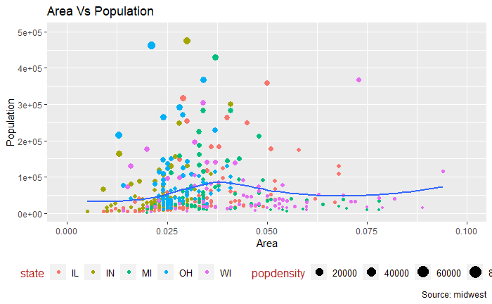

```r
# Base Plot
ggplot(midwest, aes(x=area, y=poptotal)) +
  geom_point(aes(col=state, size=popdensity)) +
  geom_smooth(method="loess", se=F) + xlim(c(0, 0.1)) + ylim(c(0, 500000)) +
  labs(title="Area Vs Population", y="Population", x="Area", caption="Source: midwest")+
  theme(legend.position="bottom", legend.box = "horizontal",legend.title = element_text(size=12, color = "firebrick"),   legend.text = element_text(size=10),)
```

GGrepel to display labels of the points inside the plot.

[figure not shown]

```r
# Filter required rows.
library(ggrepel)
midwest_sub <- midwest[midwest$poptotal > 300000, ]
midwest_sub$large_county <- ifelse(midwest_sub$poptotal > 300000, midwest_sub$county, "")

ggplot(midwest, aes(x=area, y=poptotal)) +
  geom_point(aes(col=state, size=popdensity)) +
  geom_smooth(method="loess", se=F) + xlim(c(0, 0.1)) + ylim(c(0, 500000)) +
  labs(title="Area Vs Population", y="Population", x="Area", caption="Source: midwest")+
  geom_label_repel(aes(label=large_county),
                   size=2, data=midwest_sub)
```

It is also easy to flip to plot without struggle, with the command *cord_flip*

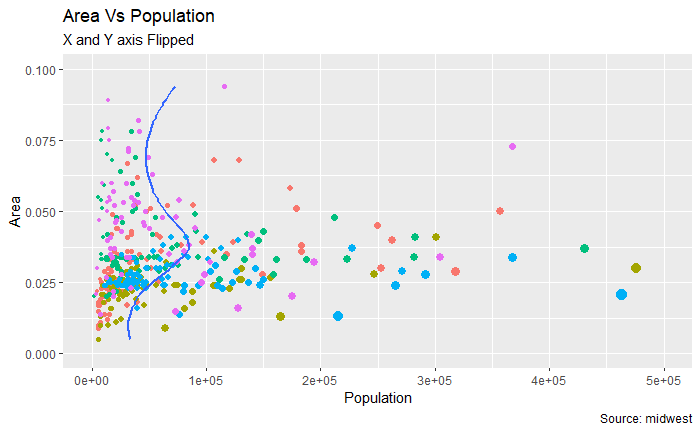

```r
ggplot(midwest, aes(x=area, y=poptotal)) +
  geom_point(aes(col=state, size=popdensity)) +
  geom_smooth(method="loess", se=F) + xlim(c(0, 0.1)) + ylim(c(0, 500000)) +
  labs(title="Area Vs Population", y="Population", x="Area",
       caption="Source: midwest", subtitle="X and Y axis Flipped") +
  theme(legend.position = "None") +
  coord_flip() # COORD_FLIP!
```

Using *facet_wrap* we can plot multiple graph according to some other variable! the command **scale=free** allows that each term has its own scale!

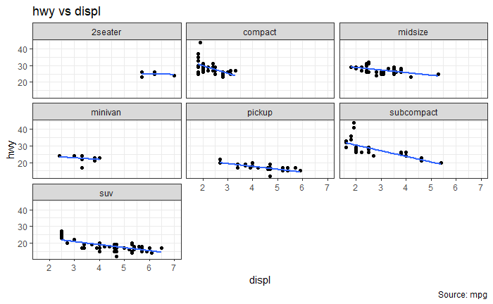

```r
data(mpg, package="ggplot2")  # load data

ggplot(mpg, aes(x=displ, y=hwy)) +
      geom_point() +
      labs(title="hwy vs displ", caption = "Source: mpg") +
      geom_smooth(method="lm", se=FALSE) +
      theme_bw()+
      facet_wrap(~ class, nrow=3)
```